# Welcome to the Documentation!

12/19/2019

# Preface

## Hello World!

# Data Prep & Management

This project uses weather and pollution data from remotely sensed satellite imagery, but also ground based sensors maintained by the EPA and FAA to model air quality in the Midwest. Using the ground sensors, the team can attempt to predict pollutions levels based on satellite data. This chapter focuses on how weather and pollution data from ground sensors was downloaded and prepared for use in refining the prediction.

## EPA Pollution Data

EPA data was seamlessly imported into R using the **aqsr** package by [Joshua P. Keller](https://github.com/jpkeller) at Colorado State University. The package takes advanatge of the [EPA AQS DataMart API](https://aqs.epa.gov/aqsweb/documents/data_mart_welcome.html) to load data in R as data.frame objects with only a couple lines of code. It allows users to query for sensor data across multiple air quality variables, geographies, and timeframes. Let’s get started by downloading the package.

```r
devtools::install_github("jpkeller/aqsr")
library(aqsr)
```

### Getting Started

This section describes the process for querying EPA sensor data using the **aqsr** package. For more information on how each function works, please reference the package documentation.

#### Obtaining an API Key

For first time users of the AQS DataMart API, you must first register your email to recieve an API key. (Users who already have a DataMart API key, please skep to the next step). The API key is a required input for all querying functions in the **aqsr** package. Obtaining a key is made simple by calling the *aqs_signup()* function and inputting your own email address.

```r
aqs_signup('YourEmailHere@uchicago.edu')
```

Save your API key from the email confirmation for future reference. In case you don’t recieve an email, verify that your email address was typed correctly, and check your spam folder.

#### Using your API Key in **aqsr**

Setup your AQI key with the **aqr** package by using the *create_user()* function. This way, you won’t have to keep typing your email and API key each time you query for data.

```r
myuser = create_user(email = 'YourEmailHere@uchicago.edu', key = 'apikey123')
```

### PM2.5 Data Query

This section describes how to query for PM2.5 concetration data from EPA pollution sensors. We are looking for at PM2.5 data Wisconsin, Illinois, and Indiana between 2014 and 2018 for our project. First, let’s start small and query only for Illinois data for the first week of 2018.

```r
IL.data = aqs_dailyData_byState(aqs_user = myuser,    # Previously defined user emailand API key
                                param = 88101,        # EPA AQS Parameter Code for PM2.5
                                bdate = "20180101",   # Starting Date (Jan 1st ,2018)
                                edate = "20180107",   # Ending Date (Jan 7th, 2018)
                                state = "17")         # State FIPS Code for Illinois


IL.data[1,]
```

```
##   state_code county_code site_number parameter_code poc latitude longitude datum                parameter sample_duration pollutant_standard date_local            units_of_measure
## 2         17         115        0013          88101   3 39.86683 -88.92559 WGS84 PM2.5 - Local Conditions   24-HR BLK AVG  PM25 24-hour 2006 2018-01-03 Micrograms/cubic meter (LC)
##   event_type observation_count observation_percent validity_indicator arithmetic_mean first_max_value first_max_hour aqi method_code
## 2       None                 1                 100                  Y            12.1            12.1              0  51         183
##                                                             method local_site_name site_address    state county    city cbsa_code        cbsa date_of_last_change
## 2 Thermo Scientific 5014i or FH62C14-DHS w/VSCC - Beta Attenuation    IEPA TRAILER 2200 N. 22ND Illinois  Macon Decatur     19500 Decatur, IL          2019-01-24
```

```r
library(dplyr)

# List of States to Iterate Through
states = c("17", "18", "55")

# Matrix of Start Dates and End Dates to Iterate Through
dates = matrix(c("20140101", "20141231", "20150101", "20151231", "20160101", "20161231", "20170101", "20171231", "20180101", "20181231"), ncol = 2, byrow = TRUE)

# Leveraging apply functions to iterate through both states and dates
full.data = lapply(states, function(x){

                mapply(aqs_dailyData_byState,
                       bdate = dates[,1],
                       edate = dates[,2],
                       MoreArgs = list(aqs_user = myuser,
                                       param = 88101,
                                       state = x),
                       SIMPLIFY = FALSE

                ) %>%
                        do.call("rbind", .)
        }) %>%
                do.call("rbind", .)
```

## FAA Weather Data

FAA weather data gathered from the [Automated Surface Observing System (ASOS)](https://en.wikipedia.org/wiki/Automated_airport_weather_station) can be imported using the **riem** package. This package, created by [ROpenSci](https://ropensci.org/), queries weather data from the [Iowa Environmental Mesonet](https://mesonet.agron.iastate.edu/ASOS/), an online portal for international ASOS data maintained by Iowa State University. First, let’s load the package.

```r
devtools::install_github('ropensci/riem')
library(riem, quietly = TRUE)
```

### Sample Query

Below is an R code snippet that performs the simplest weather data query possible in the **riem** package. It specifies a particular weather station using an airport code and a date range to query for. The output is a tibble table of raw ASOS weather data. The code snippet below extracts sensor data at the San Francisco International Airport.

```r
SFO.weather = riem_measures(station = 'KSFO', date_start = "2014-01-01", date_end = '2014-01-02')
head(SFO.weather)
```

```
## # A tibble: 6 x 31
##   station valid                 lon   lat  tmpf  dwpf  relh  drct  sknt  p01i  alti  mslp  vsby gust  skyc1 skyc2 skyc3 skyc4 skyl1 skyl2 skyl3 skyl4 wxcodes ice_accretion_1…
##   <chr>   <dttm>              <dbl> <dbl> <dbl> <dbl> <dbl> <dbl> <dbl> <dbl> <dbl> <dbl> <dbl> <lgl> <chr> <chr> <chr> <lgl> <dbl> <dbl> <dbl> <lgl> <lgl>   <lgl>
## 1 SFO     2014-01-01 00:56:00 -122.  37.6  54.0  43.0  66.3   290     8     0  30.2 1021.    10 NA    SCT   <NA>  <NA>  NA    20000    NA    NA NA    NA      NA
## 2 SFO     2014-01-01 01:56:00 -122.  37.6  52.0  43.0  71.3   280     9     0  30.2 1022.    10 NA    FEW   <NA>  <NA>  NA    20000    NA    NA NA    NA      NA
## 3 SFO     2014-01-01 02:56:00 -122.  37.6  51.1  44.1  76.8   290     8     0  30.2 1022.    10 NA    CLR   <NA>  <NA>  NA       NA    NA    NA NA    NA      NA
## 4 SFO     2014-01-01 03:56:00 -122.  37.6  48.9  37.9  65.7     0     0     0  30.2 1022.    10 NA    CLR   <NA>  <NA>  NA       NA    NA    NA NA    NA      NA
## 5 SFO     2014-01-01 04:56:00 -122.  37.6  50    39.9  68.2     0     0     0  30.2 1022.    10 NA    CLR   <NA>  <NA>  NA       NA    NA    NA NA    NA      NA
## 6 SFO     2014-01-01 05:56:00 -122.  37.6  48.9  37.0  63.4     0     0     0  30.2 1022.    10 NA    CLR   <NA>  <NA>  NA       NA    NA    NA NA    NA      NA
## # … with 7 more variables: ice_accretion_3hr <lgl>, ice_accretion_6hr <lgl>, peak_wind_gust <lgl>, peak_wind_drct <lgl>, peak_wind_time <lgl>, feel <dbl>, metar <chr>
```

The outputted table shows weather data for a 24-hour period on January 1st, 2014 at the San Francisco International Airport. The *valid* column species when each weather report was generated, typically at 1-hour intervals. The *tmpf* and *dwpf* columns give the ambient air temperature and dew point in Fahrenheit (ºF). Other important variables in our project include air pressure (*alti*), measured in inches of mercury (in.Hg), and visibility (*vsby*) in miles. For more information on all available varibles, see Iowa State’s [Documentation](https://mesonet.agron.iastate.edu/request/download.phtml).

Next, we will apply this function at a large scare across multiple sensors and timescales.

### Finding ASOS Sensors

The FAA collects weather data at hourly intervals for each meteorological station, with some stations providing half-hour intervals. Even querying for short periods of time can yield large amounts of data. To optimise performance, we want to only query data from stations in our study area.

#### Finding Sensors by State

In our project, we focus on certain counties in Illinois, Indiana, and Wisconsin, so we are interested in finding the sensors within that study area. The first step is to query the locations of all weather stations in the three states using the **riem** package. In the example below, we query for sensors in the Illinois ASOS sensor network.

```r
riem_stations(network = 'IL_ASOS')[1:3,]
```

```
## # A tibble: 3 x 4
##   id    name               lon   lat
##   <chr> <chr>            <dbl> <dbl>
## 1 ALN   ALTON/ST LOUIS R -90.0  38.9
## 2 BMI   BLOOMINGTON/NORM -88.9  40.5
## 3 CPS   CAHOKIA/ST LOUIS -90.2  38.6
```

To query for data across multiple states, we are going the apply the *riem_stations* function to a list of weather station networks, as shown below.

```r
networks = list('IL_ASOS', 'IN_ASOS', 'WI_ASOS')

library(dplyr, quietly = TRUE)
station.locs = lapply(networks, riem::riem_stations) %>%
        do.call(rbind, .) # Creates a single data table as output
```

Note: You can find a list of state abbreviations by typing ‘state.abb’ in your R console.

#### Converting Latitude and Longitude Coordinates to Spatial Data

The data tables returned by the **riem** package must be converted to spatial data to determine which sensors are located in the study area. Since the lon/lat coordinates are already provided, the data table is easily converted to a spatial *sf* object.

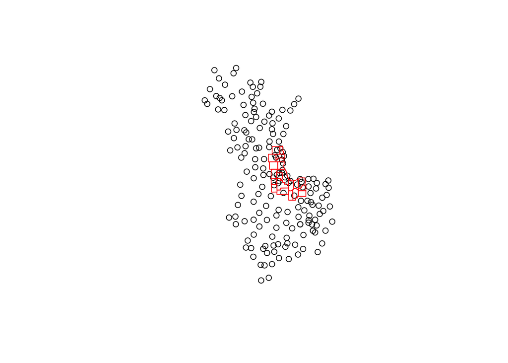

```r
station.locs.sf = sf::st_as_sf(station.locs, coords = c("lon", "lat"), crs = 4326)

# Plot stations and study area boundaries to verify that the correct sensors were selected
plot(station.locs.sf$geometry)
plot(sf::st_read('https://uchicago.box.com/shared/static/uw0srt8nyyjfqo6l0dv07cyskwmv6r50.geojson', quiet = TRUE)$geometry, border = 'red', add = TRUE)
```

We plot to results to verify that our query and data conversion process worked correctly. For reference, the boundaires of the study area is outlined in red.

#### Selecting Sensors within our Study Area

Next, we perform a spatial join to only keep the points located within the boundaries of our study area polygons. The spatial join is completed by the **sf** package, as shown below. For more information regarding spatial joins and spatial predicates, please see [this](https://gisgeography.com/spatial-join/) helpful blog post by GISgeography.com.

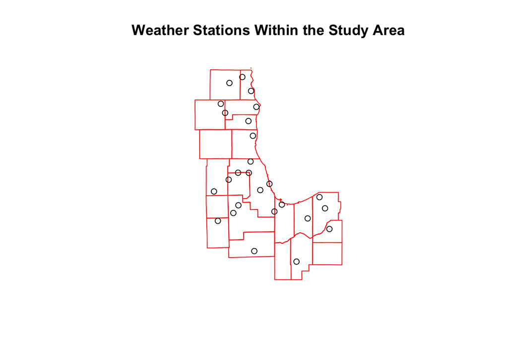

```r
# Loading study area boundaries
study.area = sf::st_read('https://uchicago.box.com/shared/static/uw0srt8nyyjfqo6l0dv07cyskwmv6r50.geojson', quiet = TRUE)

study.sensors = sf::st_join(station.locs.sf, study.area, left = FALSE)

# Verify Spatial Join by Plotting
plot(study.area$geometry, border = 'red')
plot(study.sensors$geometry, add = TRUE)
title('Weather Stations Within the Study Area')
```

Now that we have a dataset of which weather stations we are interested in, we can query for the weather data associated with each station.

### Weather Data Query

Again we use the *lapply* function in base R to execute the *riem_measures* function on a list of sensor IDs. This allows us to iteratively query for weather data from each individual sensor in a list. In the code snippet below, we take the study sensors obtained previously and query for a single day’s worth of weather data.

```r
library(dplyr, quietly = TRUE)

weather.data = lapply(study.sensors$id, function(x){riem::riem_measures(x, date_start = "2014-01-01", date_end = "2014-01-02")}) %>%
        do.call(rbind, .) # Creates a single data table as output
weather.data[1:3,]
```

```
## # A tibble: 3 x 31
##   station valid                 lon   lat  tmpf  dwpf  relh  drct  sknt   p01i  alti  mslp  vsby  gust skyc1 skyc2 skyc3 skyc4 skyl1 skyl2 skyl3 skyl4 wxcodes ice_accretion_1…
##   <chr>   <dttm>              <dbl> <dbl> <dbl> <dbl> <dbl> <dbl> <dbl>  <dbl> <dbl> <dbl> <dbl> <dbl> <chr> <chr> <chr> <lgl> <dbl> <dbl> <dbl> <lgl> <chr>              <dbl>
## 1 MDW     2014-01-01 00:49:00 -87.8  41.8  12.2  8.6   85.2   230     3 0.01    30.3   NA      2    NA FEW   BKN   OVC   NA     2500  3100  5500 NA    -SN BR                NA
## 2 MDW     2014-01-01 00:51:00 -87.8  41.8  12.9  8.96  83.8   230     3 0.01    30.3 1029.     2    NA FEW   BKN   OVC   NA     2500  3100  5500 NA    -SN BR                NA
## 3 MDW     2014-01-01 01:51:00 -87.8  41.8  12.9  8.96  83.8   280     3 0.0001  30.3 1030.     2    NA FEW   OVC   <NA>  NA     3300  5000    NA NA    -SN BR                NA
## # … with 7 more variables: ice_accretion_3hr <lgl>, ice_accretion_6hr <dbl>, peak_wind_gust <lgl>, peak_wind_drct <lgl>, peak_wind_time <lgl>, feel <dbl>, metar <chr>
```

#### Querying Full Weather Dataset

Use caution when querying for a large amount of data. Data tables can easily become unwieldy after querying for a large number of weather stations across a wide time scale. The code snippet below downloads all ASOS weather data for sensors in our study area from January 1st 2014 to December 31st 2018, which is our study time period. It has approximately 4.8 Million records and takes 6-10 minutes to download.

```r
weather.data = lapply(study.sensors$id, function(x){riem::riem_measures(x, date_start = "2014-01-01", date_end = "2018-12-31")}) %>%
        do.call(rbind, .) # Creates a single data table as output
```

# Merging Satellite and Point Sensor Data

There’s a fundamental challenge in our project to merge AOD data and predictor variables because the data capture techniques are very different. The satelite-based AOD data is measured continously across the surface of the earth on a 1km by 1km grid system. Meanwhile, sensor data is only captured locally at the sensor location. Therefore, a method to interpolate local sensor data to generate a continuous surface of data is required.

An ‘Optimized’ IDW interpolation was used to estimate sensor values across a 1km by 1km grid system. This method takes into account the sensor locations and value for each variable to estimate values in grid cells without a sensor based on a linear interpolation of nearby sensor values. The specific number of sensors to take into account and the distance decay power function were optimized by minimizing the RMSE (Error). This method was adapted from an [RSpatial Tutorial](https://rspatial.org/raster/analysis/4-interpolation.html#calfornia-air-pollution-data) on IDW interpolation with pollution and weather data.

```r
devtools::install_url('https://uchicago.box.com/shared/static/rtt6ofsm2j9dgob2qykck5yda0c89ayl.tar.gz')
library(sensor2raster)
```